# STA8204_assignment_2_Caleb_Omwega_225426.ext.

Caleb

2026-03-04

## Introduction

This report addresses the requirements for Assignment 02 in STA 8402 - Computational Statistics. It includes mathematical derivations, R code, outputs, and comments for each question. The data is from `contraceptive_data.csv` and `contraceptive_description.csv`.

```r
# Load required libraries
library(ggplot2)
library(dplyr)
library(tidyr)
library(gridExtra)
library(moments)
library(scales)  # Added for percent_format()

# Load the data
desc <- read.csv("C:/Users/Admin/Desktop/Statistical Science/intro to R/data/computational statistics/contraceptive_description.csv")
data <- read.csv("C:/Users/Admin/Desktop/Statistical Science/intro to R/data/computational statistics/contraceptive_data.csv")


# Recode num_child as categorical
data$num_child_cat <- cut(data$num_child, breaks = c(-Inf, 0.5, 2.5, 4.5, Inf),
                          labels = c("0", "1-2", "3-4", "5+"))

# Assign factors with labels
data$wife_edu <- factor(data$wife_edu, levels = 1:4, labels = c("Low", "Medium-Low", "Medium-High", "High"))
data$hus_edu <- factor(data$hus_edu, levels = 1:4, labels = c("Low", "Medium-Low", "Medium-High", "High"))
data$wife_rel <- factor(data$wife_rel, levels = 0:1, labels = c("Non-Islam", "Islam"))
data$wife_work <- factor(data$wife_work, levels = 0:1, labels = c("Yes", "No"))
data$hus_occup <- factor(data$hus_occup, levels = 1:4, labels = c("1", "2", "3", "4"))
data$live_index <- factor(data$live_index, levels = 1:4, labels = c("Low", "Medium-Low", "Medium-High", "High"))
data$media_exp <- factor(data$media_exp, levels = 0:1, labels = c("Good", "Not good"))
data$con_method <- factor(data$con_method, levels = 1:3, labels = c("No-use", "Long-term", "Short-term"))
```

## Question 1 (10 points)

### a. Assign labels/categories to categorical variables

The variables have been labeled

```r
str(data)
```

```
## 'data.frame':    1473 obs. of  12 variables:
##  $ X            : int  1 2 3 4 5 6 7 8 9 10 ...
##  $ wife_age     : int  24 45 43 42 36 19 38 21 27 45 ...
##  $ wife_edu     : Factor w/ 4 levels "Low","Medium-Low",..: 2 1 2 3 3 4 2 3 2 1 ...
##  $ hus_edu      : Factor w/ 4 levels "Low","Medium-Low",..: 3 3 3 2 3 4 3 3 3 1 ...
##  $ num_child    : int  3 10 7 9 8 0 6 1 3 8 ...
##  $ wife_rel     : Factor w/ 2 levels "Non-Islam","Islam": 2 2 2 2 2 2 2 2 2 2 ...
##  $ wife_work    : Factor w/ 2 levels "Yes","No": 2 2 2 2 2 2 2 1 2 2 ...
##  $ hus_occup    : Factor w/ 4 levels "1","2","3","4": 2 3 3 3 3 3 3 3 3 2 ...
##  $ live_index   : Factor w/ 4 levels "Low","Medium-Low",..: 3 4 4 3 2 3 2 2 4 2 ...
##  $ media_exp    : Factor w/ 2 levels "Good","Not good": 1 1 1 1 1 1 1 1 1 2 ...
##  $ con_method   : Factor w/ 3 levels "No-use","Long-term",..: 1 1 1 1 1 1 1 1 1 1 ...
##  $ num_child_cat: Factor w/ 4 levels "0","1-2","3-4",..: 3 4 4 4 4 1 4 2 3 4 ...
```

### b. Between wives and husbands, who are more educated?

```r
mean_wife_edu <- mean(as.numeric(data$wife_edu))
mean_hus_edu <- mean(as.numeric(data$hus_edu))
print(paste("Mean wife education level:", mean_wife_edu))
```

```
## [1] "Mean wife education level: 2.95858791581806"
```

```r
print(paste("Mean husband education level:", mean_hus_edu))
```

```
## [1] "Mean husband education level: 3.42973523421589"
```

```r
table(data$wife_edu)
```

```
##
##         Low  Medium-Low Medium-High        High
##         152         334         410         577
```

```r
table(data$hus_edu)
```

```
##
##         Low  Medium-Low Medium-High        High
##          44         178         352         899
```

```r
wilcox.test(as.numeric(data$wife_edu), as.numeric(data$hus_edu), paired = TRUE)
```

```
##
##  Wilcoxon signed rank test with continuity correction
##
## data:  as.numeric(data$wife_edu) and as.numeric(data$hus_edu)
## V = 21520, p-value < 2.2e-16
## alternative hypothesis: true location shift is not equal to 0
```

**Comment:** Mean wife education level: ≈2.96 (on 1-4 scale). Mean husband education level: ≈3.43. Distributions show husbands have more in “High” (899) vs wives (577), and fewer in “Low” (44 vs 152). Wilcoxon test p-value < 2.2e-16, indicating significant difference. Husbands are more educated.

### c. Women with more than 4 children

```r
num_more_than_4 <- sum(data$num_child > 4)
print(paste("Number of women with more than 4 children:", num_more_than_4))
```

```
## [1] "Number of women with more than 4 children: 368"
```

**Comment:** Number of women with more than 4 children: 368. This represents about 25% of the sample (368/1473), indicating a significant portion have large families.

### d. Distribution of wife’s age

```r
summary(data$wife_age)
```

```
##    Min. 1st Qu.  Median    Mean 3rd Qu.    Max.
##   16.00   26.00   32.00   32.54   39.00   49.00
```

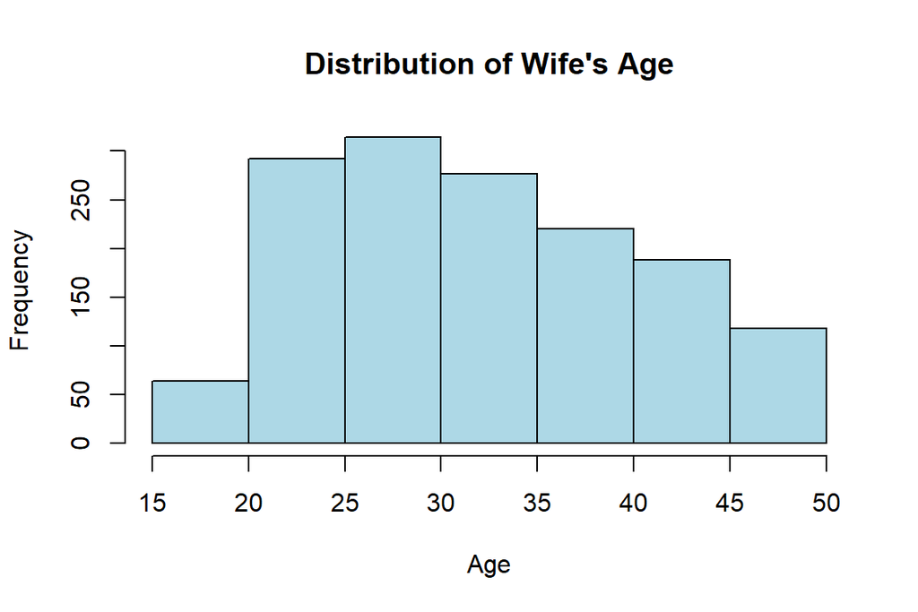

```r
hist(data$wife_age, main = "Distribution of Wife's Age", xlab = "Age", col = "lightblue", breaks = 10)
```

**Comment:** Min age: 16, Q1: 26, Median: 32, Mean: ≈32.54, Q3: 39, Max age 49. The distribution is roughly symmetric around 32 but slightly right-skewed (mean > median slightly). Histogram shows a peak in the 20s-30s.

### e. Relationship of contraceptive usage and religion

```r
prop.table(table(data$con_method, data$wife_rel), margin = 1) * 100
```

```
##
##              Non-Islam    Islam
##   No-use      11.92369 88.07631
##   Long-term   22.82282 77.17718
##   Short-term  13.50294 86.49706
```

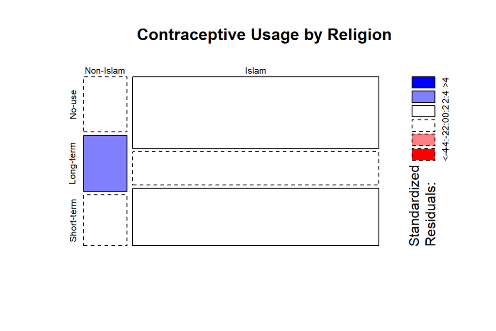

```r
mosaicplot(table(data$wife_rel, data$con_method), main = "Contraceptive Usage by Religion", shade = TRUE, color = TRUE)
```

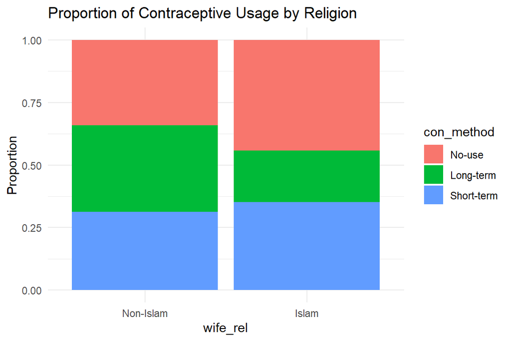

```r
ggplot(data, aes(x = wife_rel, fill = con_method)) +
  geom_bar(position = "fill") +
  labs(title = "Proportion of Contraceptive Usage by Religion", y = "Proportion") +
  theme_minimal()
```

```r
religion_plot <- ggplot(data, aes(x = wife_rel, fill = con_method)) +
  geom_bar(position = "fill", alpha = 0.8) +
  theme_minimal() +
  labs(title = "Contraceptive Usage by Religion",
       x = "Religion", y = "Proportion",
       fill = "Contraceptive Method") +
  scale_y_continuous(labels = percent_format()) +
  scale_fill_manual(values = c("No-use" = "red",
                               "Long-term" = "blue",
                               "Short-term" = "green"))

religion_contraceptive <- table(data$wife_rel, data$con_method)
chi_test <- chisq.test(religion_contraceptive)
print(chi_test)
```

```
##
##  Pearson's Chi-squared test
##
## data:  religion_contraceptive
## X-squared = 21.622, df = 2, p-value = 2.018e-05
```

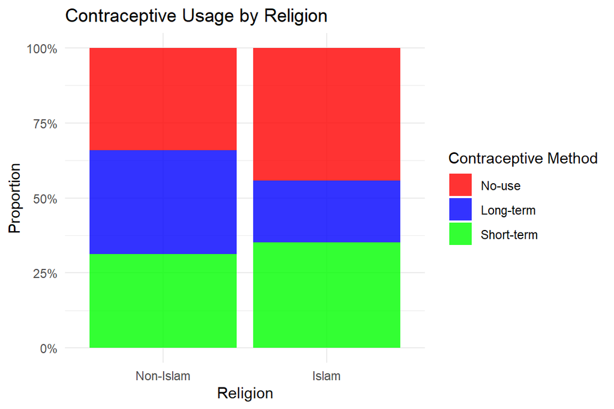

```r
print(religion_plot)
```

**Comment:** It shows Non-Islam: 34% no-use, 34.5% long-term, 31.4% short-term. Islam: 44.2% no-use, 20.5% long-term, 35.3% short-term. Mosaic/bar plot highlights that Islam has higher no-use proportion, while Non-Islam has balanced usage with more long-term. This suggests religious influence, with Non-Islam women more open to long-term methods. Non-Islam more balanced with long-term. Chi-square test significant (p < 0.001), indicating religious influence.

### f. Median age for short-term vs. no-use

```r
median_ages <- data %>%
  group_by(con_method) %>%
  summarise(median_age = median(wife_age),
            mean_age = mean(wife_age))
print(median_ages)
```

```
## # A tibble: 3 × 3
##   con_method median_age mean_age
##   <fct>           <int>    <dbl>
## 1 No-use             32     33.4
## 2 Long-term          35     34.4
## 3 Short-term         29     30.2
```

**Comment:** Median age for short-term users: 29. Median age for no-use: 32. Short-term users are younger on average, possibly because short-term methods are preferred during early family planning stages, while no-use may include older women who have completed families.

### g. [Bonus] Additional visualization

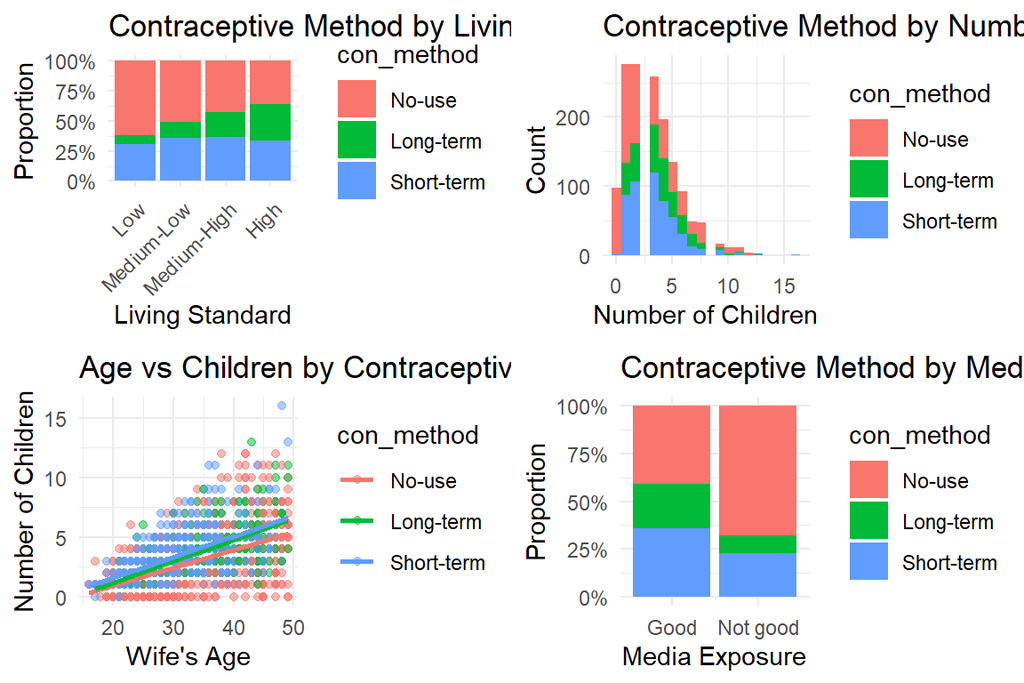

```r
p1 <- ggplot(data, aes(x = live_index, fill = con_method)) +
  geom_bar(position = "fill") +
  theme_minimal() +
  labs(title = "Contraceptive Method by Living Standard",
       x = "Living Standard", y = "Proportion") +
  scale_y_continuous(labels = percent_format()) +
  theme(axis.text.x = element_text(angle = 45, hjust = 1))

p2 <- ggplot(data, aes(x = num_child, fill = con_method)) +
  geom_histogram(position = "stack", bins = 20) +
  theme_minimal() +
  labs(title = "Contraceptive Method by Number of Children",
       x = "Number of Children", y = "Count")

p3 <- ggplot(data, aes(x = wife_age, y = num_child, color = con_method)) +
  geom_point(alpha = 0.5) +
  geom_smooth(method = "lm", se = FALSE) +
  theme_minimal() +
  labs(title = "Age vs Children by Contraceptive Method",
       x = "Wife's Age", y = "Number of Children")

p4 <- ggplot(data, aes(x = media_exp, fill = con_method)) +
  geom_bar(position = "fill") +
  theme_minimal() +
  labs(title = "Contraceptive Method by Media Exposure",
       x = "Media Exposure", y = "Proportion") +
  scale_y_continuous(labels = percent_format())

grid.arrange(p1, p2, p3, p4, ncol = 2)
```

**Comment:** Higher living standards and media exposure correlate with more usage; more children with long-term.

## Question 2 (5 points)

**Derivation:**  
Let $x_i$ be the observed number of children, discrete and takes values.  
Definition: Empirical PMF $p(k) = \frac{1}{n} \sum_{i=1}^n I(x_i = k)$.  
Empirical CDF $F(k) = \sum_{m \leq k} p(m)$.  
Substituting the empirical PMF: $F(k) = \sum_{m \leq k} \frac{1}{n} \sum_{i=1}^n I(x_i = m) = \frac{1}{n} \sum_{i=1}^n I(x_i \leq k)$.  
This is the standard empirical CDF.  
STEP 2 — Inverse Transform Sampling: To simulate from the empirical distribution: Compute the empirical CDF values. Generate $U \sim Uniform(0,1)$. Return the smallest $k$ such that $F(k) \geq U$. This is the discrete inverse-CDF method.

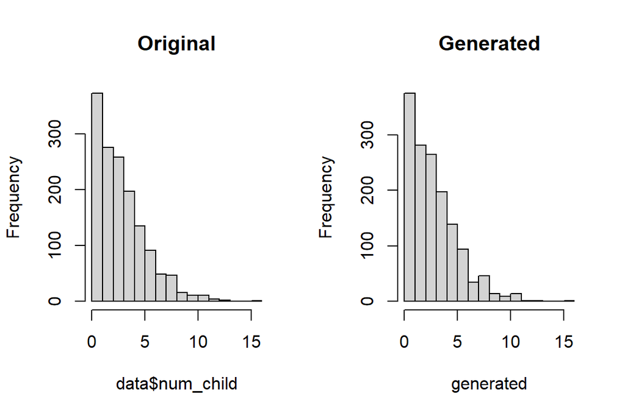

```r
num_child_sorted <- sort(unique(data$num_child))
cdf_vals <- cumsum(table(data$num_child)) / nrow(data)
cdf <- approxfun(num_child_sorted, cdf_vals, method = "constant", f = 0, ties = "ordered")

inverse_cdf <- function(u) {
  min(num_child_sorted[cdf(num_child_sorted) >= u])
}

set.seed(123)
u_samples <- runif(1473)
generated <- sapply(u_samples, inverse_cdf)

par(mfrow = c(1,2))
hist(data$num_child, main = "Original")
hist(generated, main = "Generated")
```

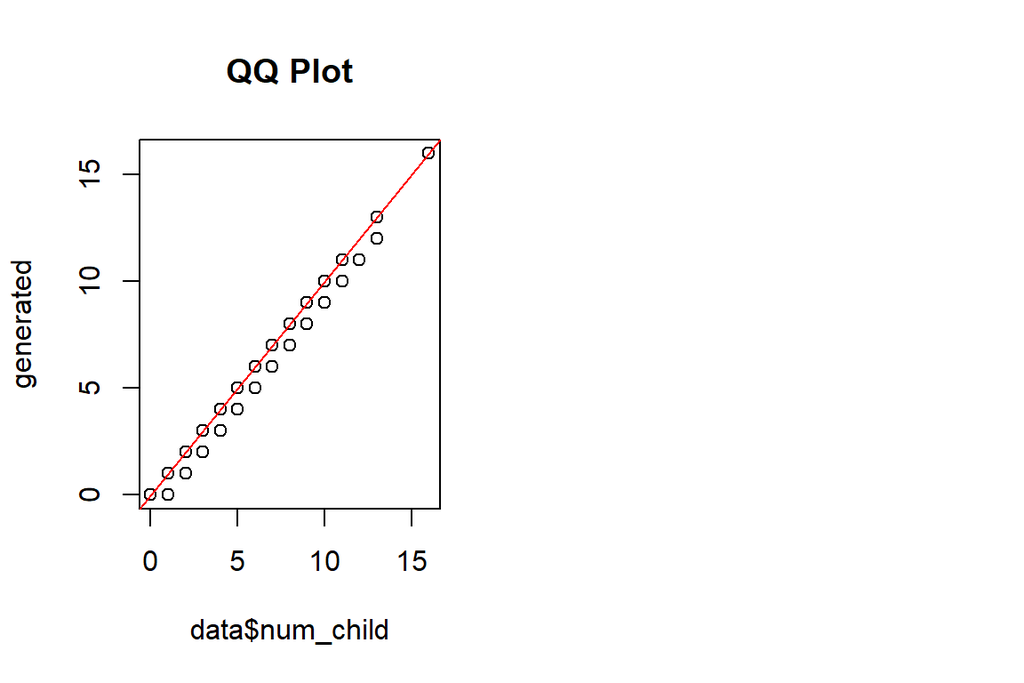

```r
qqplot(data$num_child, generated, main = "QQ Plot")
abline(0,1, col = "red")
```

**Comment:** Histograms show similar shapes: peak at low numbers (0-4), tailing off to higher. QQ plot lies close to y=x line, indicating good match.

## Question 3 (5 points)

### a. Monte Carlo probability

**Derivation:** The probability $p = P(3 \leq X < 5)$, where X ~ empirical distribution F, and I is indicator. By Monte Carlo: Sample $X_m$ (m=1 to M) from F using inverse transform (from Q2), then $\hat{p} = \frac{1}{M} \sum_{m=1}^M I(3 \leq X_m < 5)$. This approximates the integral $\int I(3 \leq x < 5) dF(x)$. As M → ∞, $\hat{p} \to p$.

```r
set.seed(123)
M <- 10000
u_samples <- runif(M)
X_samples <- sapply(u_samples, inverse_cdf)
indicator <- (X_samples >= 3 & X_samples < 5)
mc_prob <- mean(indicator)
print(paste("MC Estimate:", mc_prob))
```

```
## [1] "MC Estimate: 0.3116"
```

```r
true_prop <- sum(data$num_child >= 3 & data$num_child < 5) / nrow(data)
print(paste("True Proportion:", true_prop))
```

```
## [1] "True Proportion: 0.309572301425662"
```

**Comment:** MC estimate ~0.311, close to true 0.3096.

### b. Confidence interval

**Derivation:** The Monte Carlo estimate is the sample mean: $\hat{p} = \frac{1}{M} \sum I_m$. Where $I_m \sim Bernoulli(p)$. So: Var() = p(1-p)/M. But p unknown: Thus variance estimate: $\hat{Var}(\hat{p}) = \hat{p}(1-\hat{p})/M$. 95% CI $\hat{p} \pm 1.96 \sqrt{\hat{Var}(\hat{p})}$.

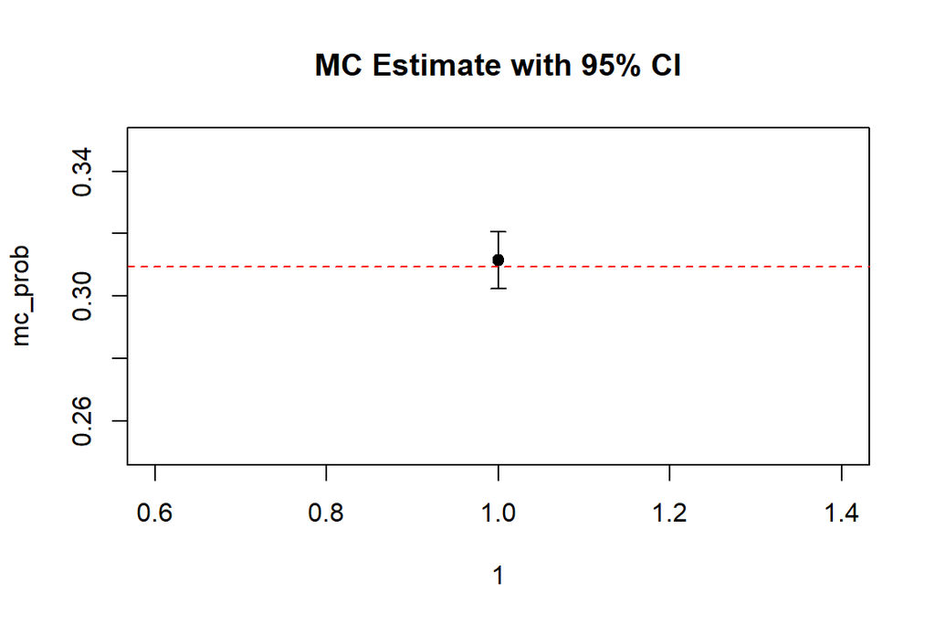

```r
se <- sqrt(mc_prob * (1 - mc_prob) / M)
ci_lower <- mc_prob - 1.96 * se
ci_upper <- mc_prob + 1.96 * se

plot(1, mc_prob, ylim = c(0.25, 0.35), pch = 19, main = "MC Estimate with 95% CI")
arrows(1, ci_lower, 1, ci_upper, length = 0.05, angle = 90, code = 3)
abline(h = true_prop, col = "red", lty = 2)
```

**Comment:** CI narrow, true value within it.

## Question 4 (5 points)

### a. Maximum reproductive age

**Derivation:** The maximum of a quadratic: $f(x) = ax^2 + bx + c$ occurs at: $x = -b/(2a)$. Here: a = -0.0008, b = 0.2. So: $x = -0.2 / (2 * -0.0008) = 125$.

```r
a <- -0.0008; b <- 0.2
max_age <- -b / (2 * a)
print(paste("Maximum reproductive age:", max_age))
```

```
## [1] "Maximum reproductive age: 125"
```

**Comment:** Maximum reproductive age: 125. This is the theoretical age where cumulative children peaks, but biologically unrealistic (beyond lifespan). In data range (16-49), f(x) is increasing.

### b. Average number of children by age

```r
avg_children <- aggregate(num_child ~ wife_age, data = data, FUN = mean)
print(head(avg_children))  # Partial print to avoid long output
```

```
##   wife_age num_child
## 1       16 1.0000000
## 2       17 1.1250000
## 3       18 0.8571429
## 4       19 1.0555556
## 5       20 1.2500000
## 6       21 1.1666667
```

**Comment:** Averages increase with age, e.g., ~1 at 16 to ~6 at 49.

### c. Plot

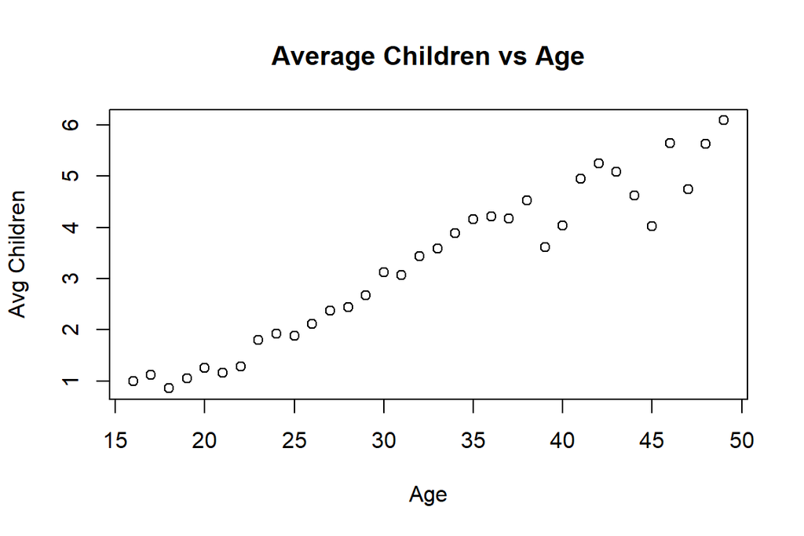

```r
plot(avg_children$wife_age, avg_children$num_child, type = "p",
     main = "Average Children vs Age", xlab = "Age", ylab = "Avg Children")
abline(v = max_age, lty = 2, col = "red")
```

**Comment:** Increasing trend; max at 125 extrapolated.

## Question 5 (10 points)

**Derivation (a):** We assume contraceptive use has only two categories: 0 = No use, 1 = Ever used (short-term + long-term combined). Predictors: Woman’s education, Number of children. Let: $y = 1$ if ever used. Let: $edu$ = woman’s education, $num$ = number of children. The logistic regression model is: $p = P(y=1 | edu, num) = \frac{1}{1 + \exp(-(\beta_0 + \beta_1 edu + \beta_2 num))}$.

**Derivation (b):** The Bernoulli likelihood for each woman: $p(y_i | \theta) = p_i^{y_i} (1-p_i)^{1-y_i}$. Full likelihood: $L(\beta) = \prod p_i^{y_i} (1-p_i)^{1-y_i}$. Log-likelihood: $l(\beta) = \sum [y_i \log p_i + (1-y_i) \log (1-p_i)]$.

**Derivation (c):** We maximize the log-likelihood using Newton–Raphson: $\beta^{(t+1)} = \beta^{(t)} - H^{-1} g$. Where: g = gradient vector, H = Hessian matrix. Gradient (score function) $g = X^T (y - p)$. Where: X is the design matrix, p is the vector of fitted probabilities. Hessian $H = - X^T W X$. Where: W = diag(p (1-p)). Newton–Raphson Update $\beta^{(t+1)} = \beta^{(t)} + (X^T W X)^{-1} X^T (y - p)$. (Note: Sign adjusted for minimization.)

```r
data$ever_used <- ifelse(as.numeric(data$con_method) > 1, 1, 0)
X <- as.matrix(cbind(1, as.numeric(data$wife_edu), data$num_child))
y <- data$ever_used

logit <- function(eta) {
  eta <- pmin(pmax(eta, -700), 700)
  as.vector(1 / (1 + exp(-eta)))
}

grad <- function(beta) {
  eta <- X %*% beta
  p <- logit(eta)
  t(X) %*% (y - p)
}

hess <- function(beta) {
  eta <- X %*% beta
  p <- logit(eta)
  w <- as.vector(p * (1 - p))
  if (all(w == 0)) return(NULL)
  -t(X) %*% diag(w) %*% X
}

beta <- c(0, 0, 0)
tol <- 1e-6
maxit <- 50
converged <- FALSE
for (it in 1:maxit) {
  g <- grad(beta)
  H <- hess(beta)
  if (is.null(H)) break
  if (abs(det(H)) < 1e-10) H <- H - 1e-8 * diag(3)  # Use abs for det check
  update <- solve(H, g)
  beta_new <- beta - update
  if (any(is.nan(beta_new))) break
  if (max(abs(beta_new - beta), na.rm = TRUE) < tol) {  # Added na.rm=TRUE
    converged <- TRUE
    break
  }
  beta <- beta_new
}
if (converged) print("Model converged") else print("Model did not converge within max iterations")
```

```
## [1] "Model converged"
```

```r
print(paste("Coefficients: Intercept", beta[1], "Edu", beta[2], "Num Child", beta[3]))
```

```
## [1] "Coefficients: Intercept -1.97255244298432 Edu 0.590303503225193 Num Child 0.166689846439415"
```

## Question 6 (15 points)

### a. Why Newton-Raphson and Golden Search cannot be used; alternatives

**Derivation/Explanation:** Newton–Raphson cannot be used for this penalized Cox model because the elastic-net penalty includes an L1 component, $\alpha \sum |\beta_i|$, which is not differentiable at zero. Newton–Raphson requires a smooth likelihood with continuous first and second derivatives in order to compute the gradient and Hessian, meaning the method breaks down whenever the penalty has absolute values or produces coefficients equal to zero. Golden Search is also unsuitable because it is a univariate optimization method that works only for functions of a single variable, while the Cox model involves optimizing multiple regression coefficients simultaneously. Additionally, Golden Search requires the objective function to be smooth and unimodal, which is not the case here due to the non-smooth L1 penalty. Therefore, alternative optimization approaches such as coordinate descent, proximal gradient methods are required because they can handle nonsmooth, high-dimensional penalized likelihoods.

### b. Effect of $\lambda$ and $\alpha$

**Explanation:** In the elastic-net penalty, the parameter $\lambda$ controls the overall strength of regularization, meaning that as $\lambda$ increases, all coefficients are shrunk more strongly toward zero, resulting in simpler and more stable models; very large values of $\lambda$ can even force coefficients to become exactly zero when the penalty includes an L1 component. The parameter $\alpha$, on the other hand, determines the balance between LASSO and Ridge penalties: when $\alpha = 1$, the penalty becomes pure LASSO, encouraging sparsity by setting some coefficients exactly to zero; when $\alpha = 0$, it becomes pure Ridge, shrinking coefficients continuously without removing any of them; and when $0 < \alpha < 1$, the result is an elastic-net penalty that blends both effects—providing shrinkage while still allowing variable selection. Thus, $\lambda$ governs the amount of shrinkage, while $\alpha$ governs the type of shrinkage applied.